# Section 1 - Question 1

This exercise must be done with pen and paper (or with pen and Word) as you have to indicate the calculations you have done.

1. Represent the following directed graph by means of (a) and adjacency matrix and (b) and adjacency list.

(a) Adjacency Matrix: 1 2 3 4 5 6 7 8 9 10 1 0 1 0 0 1 0 0 0 0 1 2 0 0 0 0 0 0 0 0 0 0 3 0 0 0 1 0 0 0 0 0 0 4 0 1 0 0 1 0 0 0 0 0 5 1 0 0 0 0 0 0 0 0 0 6 0 0 0 0 0 0 0 0 0 1 7 0 0 0 0 0 1 0 1 1 0 8 0 0 0 0 0 0 0 0 0 0 9 0 0 0 0 0 0 0 1 0 0 10 1 0 0 0 0 1 0 0 0 0 (b) Adjacency list: 1 - 2 - 5 - 10 2 3 - 4 4 - 2 - 5 5 - 1 6 - 10 7 - 6 - 8 - 9 8 9 - 8 10 - 1 - 6

# Section 1 - Question 2

# Section 1 - Question 3

# Section 2

1. Download the CaernoElegans-LC_uw.txt graph from Moodle, the graph contains a protein interaction network corresponding to the Caernobidis Elegans worm.

2. The file that contains the network is in edge list format, therefore, load the graph in a variable G_CE using the function read_edgelist ("CL-LC_uw.txt").

```python
import networkx as nx
G_CE = nx.read_edgelist ("CaernoElegans-LC_uw.txt")
```

3. Obtain:  
a) print the order  
b) print the size of the graph by the output  
c) find out whether the graph is directed or not.  
d) Is it a dense or sparse graph?

```python
order = nx.number_of_nodes(G_CE) #a
size = nx.number_of_edges(G_CE) #b
graph_type = nx.is_directed(G_CE) #c
density = nx.density(G_CE) #d

print("The order of the graph is ",order, "and the size of the graph is ", size)
print("")
print("Is the graph directed (Ture=Yes, False=No) = ", graph_type)
print("")
print("The density of the graph is ",density)
```

```
The order of the graph is  1387 and the size of the graph is  1648

Is the graph directed (Ture=Yes, False=No) =  False

The density of the graph is  0.001714539566017576
```

4. Create a random graph G_AL that has the same order and size as the graph that you just loaded using the function gnm_random_graph (n, m).

```python
n = nx.number_of_nodes(G_CE)
m = nx.number_of_edges(G_CE)
random = nx.gnm_random_graph(n, m)
```

5. Tell if both graphs are connected..

```python
connectedCE = nx.is_connected(G_CE)
connectedR = nx.is_connected(random)

print("Is G_CE graph connected?",connectedCE)
print("Is random graph connected?",connectedR)
```

```
Is G_CE graph connected? False
Is random graph connected? False
```

6. Compute the number of connected components of each graph.

```python
componentsCE = nx.number_connected_components(G_CE)
componentsR = nx.number_connected_components(random)
print("The number of connected components in G_CE are ",componentsCE)
print("The number of connected components in random are ",componentsR)
```

```
The number of connected components in G_CE are  89
The number of connected components in random are  139
```

7. What is the node with the highest grade in each graph?

```python
max_degree = 0
node = ""

for n, d in G_CE.degree:
    if d > max_degree:
        max_degree = d
        node = n

print("The node ",node, "has the highest degree in G_CE graph with a value of ",max_degree)

degreeR = nx.degree(random)
max_degreeR = 0
nodeR = ""

for node, degree in degreeR:
    if degree > max_degreeR:
        max_degreeR = degree
        nodeR = node

print("The node ",node, "has the highest degree in random graph with a value of ",max_degree)
```

[output not shown]

8. What is the node with the highest betweeness?

```python
import operator
betweenCE = nx.load_centrality(G_CE)
betweenR = nx.load_centrality(random)
max_betweenCE = max(betweenCE.items(), key=operator.itemgetter(1))
max_betweenR = max(betweenR.items(), key=operator.itemgetter(1))

print("The node ",max_betweenCE[0], "has the highest betweeness in G_CE graph with a value of ",max_betweenCE[1])
print("The node ",max_betweenR[0], "has the highest betweeness in random graph with a value of ",max_betweenR[1])
```

```
The node  C23G10.4 has the highest betweeness in G_CE graph with a value of  0.0844634599594112
The node  1238 has the highest betweeness in random graph with a value of  0.05242704850155721
```

9. What is the node with the highest closeness?

```python
closeCE = nx.closeness_centrality(G_CE)
closeR = nx.closeness_centrality(random)
max_closeCE = max(closeCE.items(), key=operator.itemgetter(1))
max_closeR = max(closeR.items(), key=operator.itemgetter(1))

print("The node ",max_closeCE[0], "has the highest closeness in G_CE graph with a value of ",max_closeCE[1])
print("The node ",max_closeR[0], "has the highest closeness in random graph with a value of ",max_closeR[1])
```

```
The node  W10C8.2 has the highest closeness in G_CE graph with a value of  0.13008480872167205
The node  1238 has the highest closeness in random graph with a value of  0.14442036212981432
```

10. What is the node with the highest distance between two nodes in the graph (graph diameter)?

```python
try:
    diameter = nx.diameter(G_CE)
    print("The diameter of G_CE is ",diameter)
except:
  print("As the graph G_CE is not connected, the path length is infinite")

try:
    diameter = nx.diameter(random)
    print("The diameter of the random graph is ",diameter)
except:
  print("As the random graph is not connected, the path length is infinite")
```

```
As the graph G_CE is not connected, the path length is infinite
As the random graph is not connected, the path length is infinite
```

# Section 3: Node Degree Distribution

1. Plot the node degree distribution of both graphs.

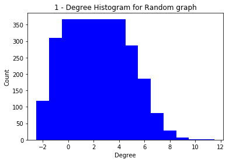

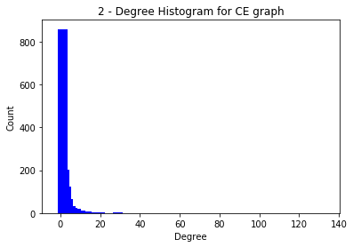

```python
import matplotlib.pyplot as plt
#Random graph
R=nx.degree_histogram(random)
plt.bar(range(len(R)),R, width=5, color='b')
plt.title("1 - Degree Histogram for Random graph")
plt.ylabel("Count")
plt.xlabel("Degree")
plt.show()

#G_CE graph
L=nx.degree_histogram(G_CE)
plt.bar(range(len(L)),L, width=5, color='b')
plt.title("2 - Degree Histogram for CE graph")
plt.ylabel("Count")
plt.xlabel("Degree")
plt.show()
```

2. Are the node degree distribution of both graphs the same?, What conclusion do you draw from the above?  
The degree distributions of both graphs are different.  
Graph 1 (the random network)  
This graph is what we would typically expect to see when we graph a random network of this size. In these simple types of networks, the nodes we find should have similar degrees. This can been clearly seen in graph 1.  
Graph 2 (G_CE netwrok)  
This graphhas a distribution more similar to a real world netwrok. In a real world network, most nodes have a relatively small degree, but a few nodes will have very large degree. These large nodes will cause the average degree to be larger. Such a degree distribution is said to have a long tail.

3. Now draw the node degree distribution of the protein interaction network using logarithmic scale in both axes,  
Add these two lines of code to change the type of scale in each axis  
plt.xscale("log", nonposx='clip')  
plt.yscale("log", nonposy='clip')

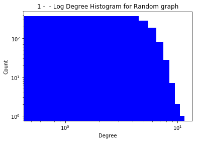

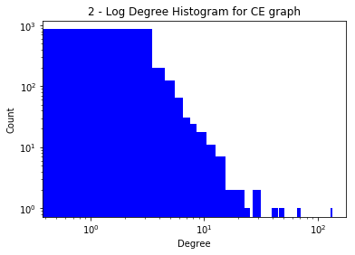

```python
#random graph
R=nx.degree_histogram(random)
plt.bar(range(len(R)),R, width=5, color='b')
plt.xscale("log", nonposx='clip')
plt.yscale("log", nonposy='clip')
plt.title("1 -  - Log Degree Histogram for Random graph")
plt.ylabel("Count")
plt.xlabel("Degree")
plt.show()


#G_CE graph
L=nx.degree_histogram(G_CE)
plt.bar(range(len(L)),L, width=5, color='b')
plt.xscale("log", nonposx='clip')
plt.yscale("log", nonposy='clip')
plt.title("2 - Log Degree Histogram for CE graph")
plt.ylabel("Count")
plt.xlabel("Degree")
plt.show()
```

4. What kind of plot do you get? Could you roughly calculate the slope of the data?  
This is a log scale graph. They both appear to be more similar here compared to before however, plot 2 had additional points on the graph with gaps between node degree distribution points

# Section 4:

Visualization of the graphs (do not expect wonders in this section, NetworkX is not very powerful nor very easy to use drawing).

1. Plot both graphs. Do you observe any differences between them?
2. Choose a layout where the difference between the graphs can be clearly observed.
3. Export both graph to a Gephy compatible file format and plot the graphs in Gephy following these steps:
   1. Download the Java file from Moodle and install it. Export both graphs in GexF format using write_gexf (G, path).
4. Load the file with Gephi indicating that it is a directed graph.
5. In the lower panel on the left side, where you put distribution (layout), select some distribution (in the case of the protein network I recommend you choose Fruchterman Reingold) and press the Execute button. Observe what happens.

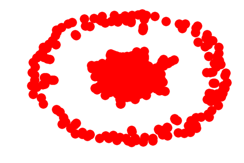

```python
nx.draw_spring(random)
```

[output not shown]

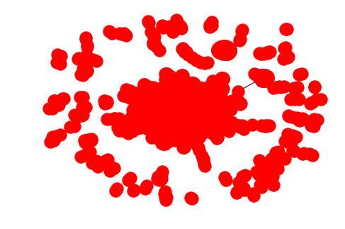

```python
print("G_CE network plot",nx.draw_spring(G_CE))
```

```python
#write the newtroks to a file and open in gephy
nx.write_gexf(G_CE,"G_CE.gexf")
nx.write_gexf(random,"random_network.gexf")
```

```
Image 1 from graph - random_network.PNG
```

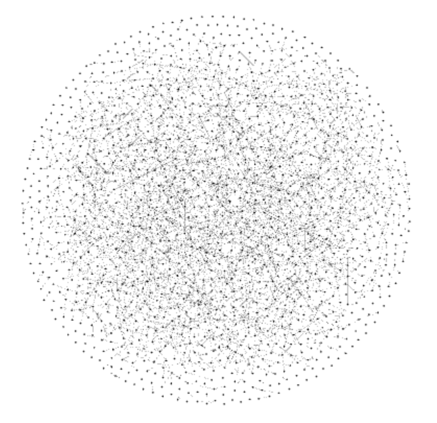

```
Image 2 from graph - G_CE.png
```

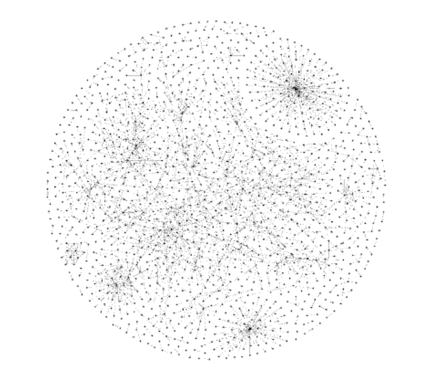

```python
from IPython.display import Image, display

listOfImageNames = ['random_network.PNG',
                   'G_CE.png']

#Printing the graphs
count=0
num=1
for imageName in listOfImageNames:
    print("Image",num,"from graph -",listOfImageNames[count])
    display(Image(filename=imageName))
    count= count+1
    num = num+1
```